# Question 8: Substance-Involved Arrests by Gender

Stor 320 group2 Q8

## Question 8

**How does the presence of drugs or alcohol at the time of arrest (as recorded in the `Drugs_Alcohol` column) vary by gender, and which gender shows a higher proportion of substance-involved arrests?**

### Load Data

```r
# Read the dataset
arrests <- read_csv("Police_Arrests_Clean.csv")

# Filter Drugs_Alcohol and remove unknowns
arrests <- read_csv("Police_Arrests_Clean.csv") %>%
  filter(
    !is.na(Gender), Gender %in% c("M", "F"),           # keep only Male and Female
    !is.na(Drugs_Alcohol), Drugs_Alcohol %in% c("Y", "N")  # keep only valid substance values
  ) %>%
  mutate(
    Substance = ifelse(Drugs_Alcohol == "Y", "Substance Present", "No Substance")
  )
```

### Summarize Proportions by Gender

```r
# Filter out unknowns if needed, then summarize
q8_summary <- arrests %>%
  group_by(Gender, Substance) %>%
  summarise(Count = n(), .groups = "drop") %>%
  group_by(Gender) %>%
  mutate(Proportion = Count / sum(Count))
```

### Visualization

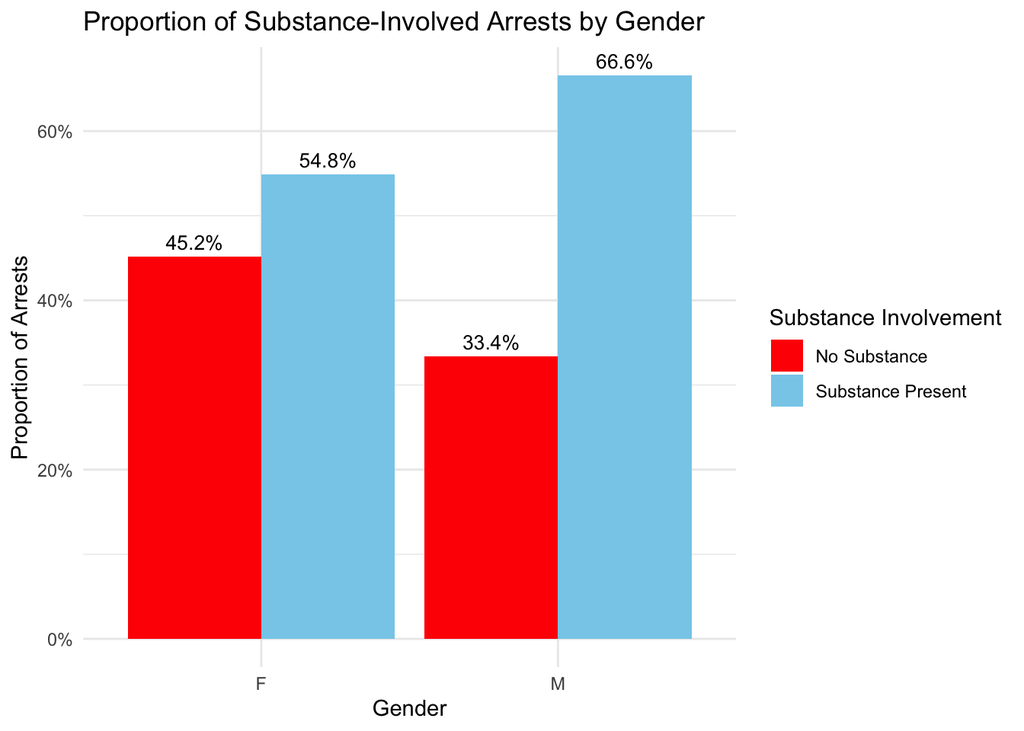

```r
ggplot(q8_summary, aes(x = Gender, y = Proportion, fill = Substance)) +
  geom_col(position = "dodge") +
  geom_text(aes(label = scales::percent(Proportion, accuracy = 0.1)),
            position = position_dodge(width = 0.9),
            vjust = -0.5, size = 3.5) +
  scale_fill_manual(
    values = c("Substance Present" = "skyblue", "No Substance" = "red")
  ) +
  labs(
    title = "Proportion of Substance-Involved Arrests by Gender",
    x = "Gender",
    y = "Proportion of Arrests",
    fill = "Substance Involvement"
  ) +
  scale_y_continuous(labels = scales::percent_format()) +
  theme_minimal()
```

### Interpretation

This plot shows the proportion of arrests involving drugs or alcohol for each gender. The data helps us identify whether substance-involved arrests are more common among one gender relative to their total arrests in Chapel Hill. Among all arrests 66.6% of male arrests involved drugs or alcohol, compared to 54.8% of Female arrests having substance involvement. This proportion reveals that substance involvement was more prevalent among males. This difference could reflect variation the types of offenses committed or a difference in how police handle males and females that are under the influence of substances.

Substance involved arrests account for more than half of Female arrests and two thirds of Male arrests indicating that drugs or alcohol play a significant role in the majority of arrest events in Chapel Hill. This implies a strong correlation between substance presence and events leading to an arrest. These findings have implications for substance abuse prevention programs and substance abuse based police training.

Potential further questions based on this investigation. 1. Can we predict the likelihood of a substance involved arrest based on gender, time of day, age, and use this to deploy substance abuse prevention resources.

2. How can trends in subtance based arrests be used to predict emerging public health challenges